# Ch. 10 Relational Data pg 171-193

Ann-Marie Zahn

October 24, 2017

### Exersizes 1: pg 174-175, #’s 1-4

###### 1.

You want to draw the route each plane flies from its origin to its destination.

Necessary Variables: origin, destination, latitude, longitude

Necessary Tables to combine: airports, planes

###### 2.

Relationship between weather and airports: weather and airports share origin. They should be connected.

###### 3.

If weather had info for all airports you would also need a relation with destination.

###### 4.

Special table would include: month, day

Primary key would have to be both month and day together

Connections: special would connect to flights (month, day) and weather (month, day)

### Excersize 2: pg. 177, #’s 1-3

###### 1.

```r
#add surrogate key to flights (create primary key)
flights <- flights %>%
  mutate(Seq = row_number())
```

###### 2.

```r
Lahman::Batting

babynames::babynames

nasaweather::atmos

fueleconomy::vehicles

ggplot2::diamonds

Lahman::TeamsFranchises
```

Lahman::Batting

- primary key: playerID
- foreign key: teamID, yearID, teamID, lgID

babynames::babynames

- primary key: name and year together
- foreign key: sex

nasaweather::atmos

- primary key: lat and long together
- foreign key: ozone, temp

fueleconomy::vehicles

- primary key: id
- foreign key: make, model

ggplot2::diamonds

- primary key: none
- foreign key: carat, cut, color, clarity, depth

###### 3.

drawing!!!!!!!

### Excersize 3: pg. 186-187, #’s 1-5

###### 1.

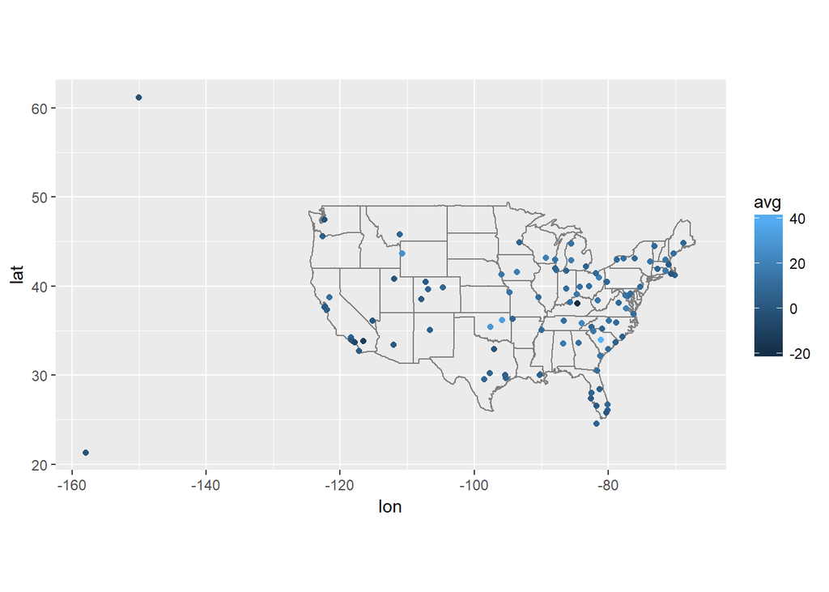

```r
flights %>%
  group_by(dest) %>%
  summarise(avg = mean(arr_delay, na.rm = TRUE)) %>%
  left_join(airports, c(  "dest" = "faa")) %>%
  ggplot(aes(lon, lat, color = avg)) +
  borders("state") +
  geom_point() +
  coord_quickmap()
```

###### 2.

```r
flights2 <- flights %>%
  left_join(airports, c(  "dest" = "faa"), suffix = c(".dest", ".origin")) %>%
  left_join(airports, c("origin" = "faa"), suffix = c(".dest", ".origin")) %>%
  select(-name.dest, -(alt.dest:name.origin), -(alt.origin:tzone.origin))
```

###### 3.

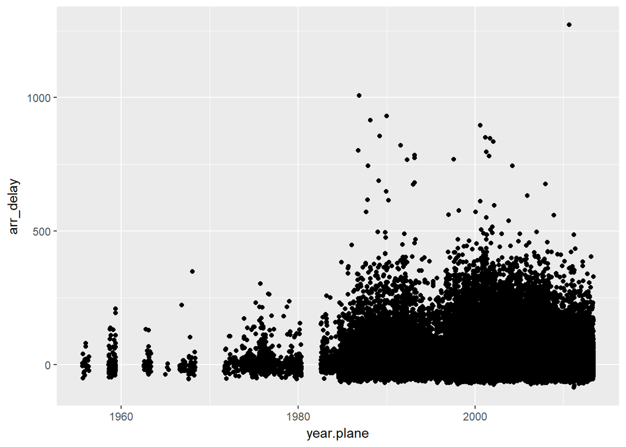

```r
flights %>%
  left_join(planes, by = "tailnum", suffix = c(".flight", ".plane")) %>%
  select(-(type:engine)) %>%
  ggplot(aes(x = year.plane, y = arr_delay)) + geom_jitter()
```

There does not seem to be a relationship between the age of a plane and its arrival delay. This may be because there are just not as many older planes still flying.

###### 4.

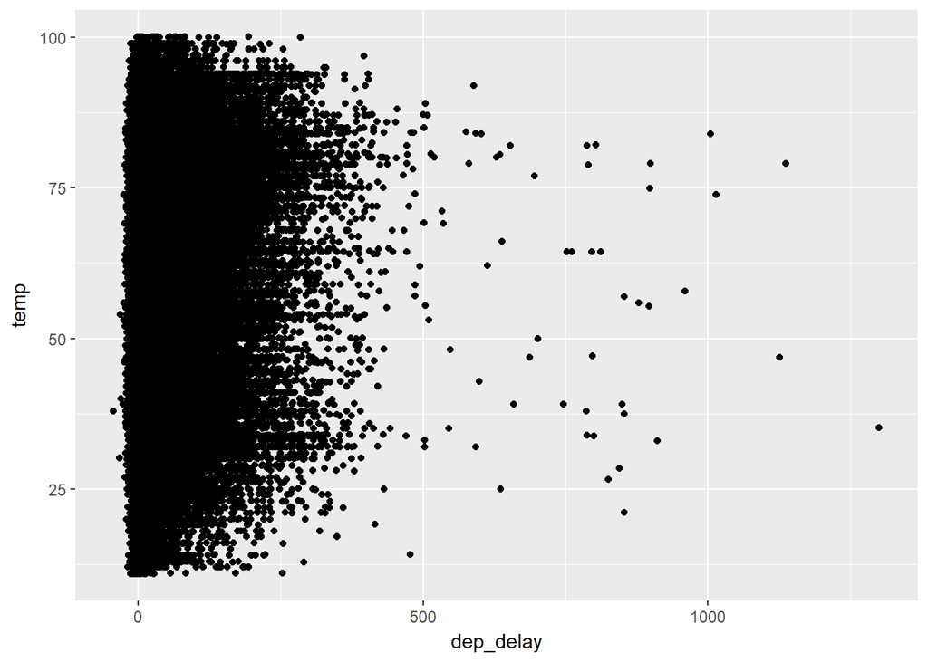

```r
flights3 <- flights %>%
  left_join(weather, by = c("time_hour", "origin"), suffix = c(".flight", ".weather"))

ggplot(data = flights3, aes(x = dep_delay)) + geom_jitter(aes(y = temp))
```

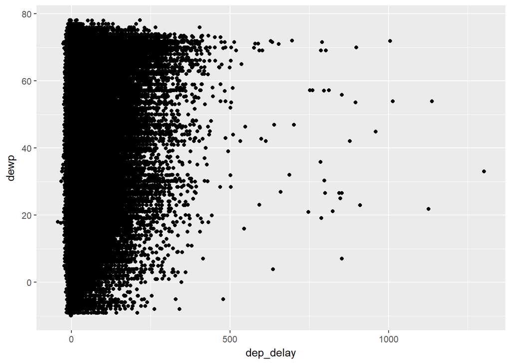

```r
ggplot(data = flights3, aes(x = dep_delay)) + geom_jitter(aes(y=dewp))
```

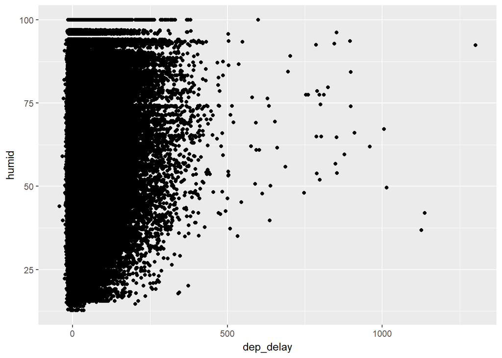

```r
ggplot(data = flights3, aes(x = dep_delay)) + geom_jitter(aes(y=humid))
```

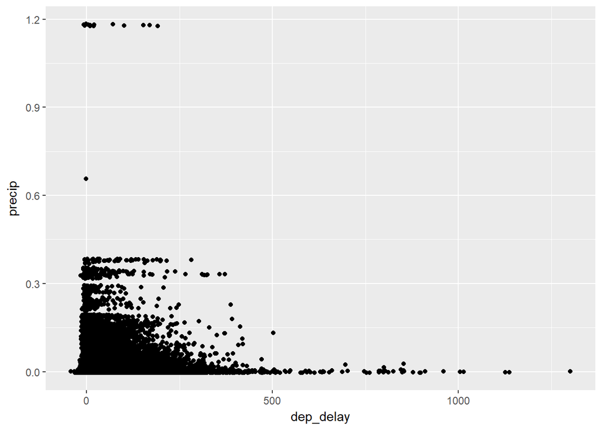

```r
ggplot(data = flights3, aes(x = dep_delay)) + geom_jitter(aes(y=precip))
```

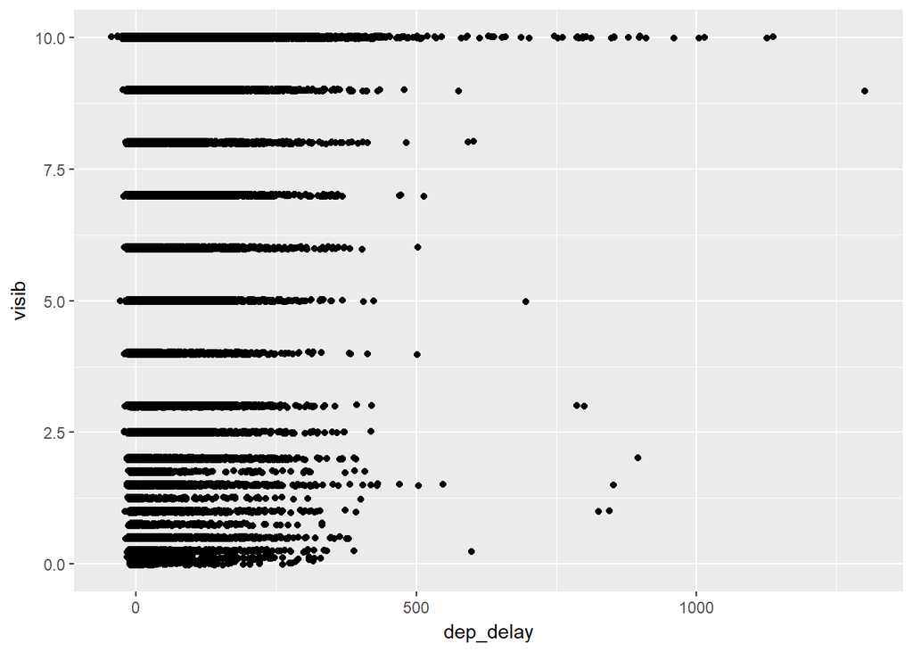

```r
ggplot(data = flights3, aes(x = dep_delay)) + geom_jitter(aes(y=visib))
```

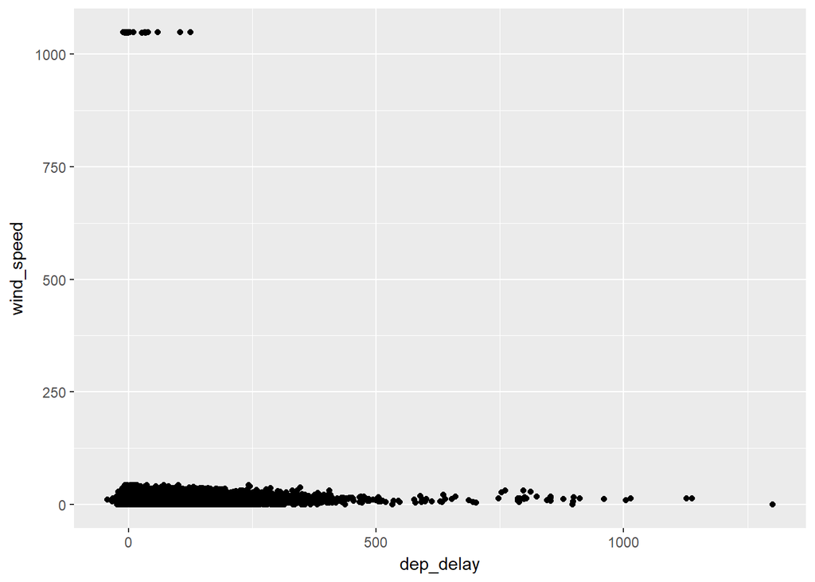

```r
ggplot(data = flights3, aes(x = dep_delay)) + geom_jitter(aes(y=wind_speed))
```

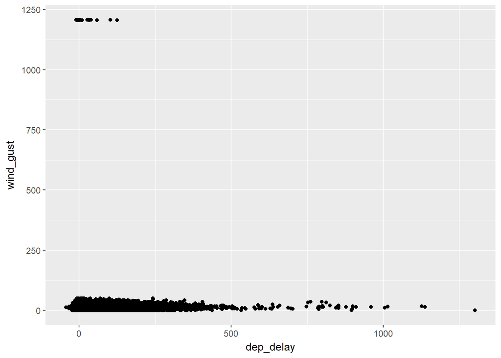

```r
ggplot(data = flights3, aes(x = dep_delay)) + geom_jitter(aes(y=wind_gust))
```

It looks like temp, visibility, and precipitation all factor into the likelihood of a delay.

###### 5.

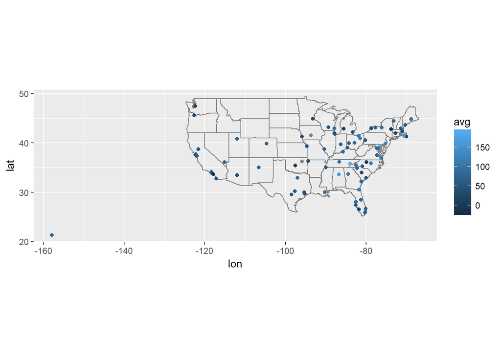

```r
flights %>%
  filter(year == 2013, month == 6, day == 13) %>%
  group_by(dest) %>%
  summarise(avg = mean(arr_delay, na.rm = TRUE)) %>%
  left_join(airports, c(  "dest" = "faa")) %>%
  ggplot(aes(lon, lat, color = avg)) +
  borders("state") +
  geom_point() +
  coord_quickmap()
```

The eastern coast experienced a lot of delays due to two derechos, which contained high winds.

### Excersize 4: pg. 191 #’s 1-6

###### 1.

```r
anti_join(flights, planes, by = "tailnum") %>%
  group_by(carrier) %>%
  count()
```

```
## # A tibble: 10 x 2
## # Groups:   carrier [10]
##    carrier     n
##      <chr> <int>
##  1      9E  1044
##  2      AA 22558
##  3      B6   830
##  4      DL   110
##  5      F9    50
##  6      FL   187
##  7      MQ 25397
##  8      UA  1693
##  9      US   699
## 10      WN    38
```

It seems that mainly AA and MQ have tailnums that are not in the planes table.

###### 2.

```r
planes_100_plus_flights <- flights %>%
  group_by(tailnum) %>%
  count() %>%
  filter(n > 100)

semi_join(flights, planes_100_plus_flights, by = "tailnum")
```

```
## # A tibble: 229,202 x 20
##     year month   day dep_time sched_dep_time dep_delay arr_time
##    <int> <int> <int>    <int>          <int>     <dbl>    <int>
##  1  2013     1     1     1604           1510        54     1817
##  2  2013     1     1     2100           2100         0     2307
##  3  2013     1     2      827            835        -8     1059
##  4  2013     1     2     2014           2020        -6     2256
##  5  2013     1     4     1621           1625        -4     1853
##  6  2013     1     5      834            835        -1     1050
##  7  2013     1     6      832            835        -3     1101
##  8  2013     1     6     2051           2100        -9     2241
##  9  2013     1     7      826            835        -9     1057
## 10  2013     1     7     1444           1445        -1     1659
## # ... with 229,192 more rows, and 13 more variables: sched_arr_time <int>,
## #   arr_delay <dbl>, carrier <chr>, flight <int>, tailnum <chr>,
## #   origin <chr>, dest <chr>, air_time <dbl>, distance <dbl>, hour <dbl>,
## #   minute <dbl>, time_hour <dttm>, Seq <int>
```

###### 3.

```r
fueleconomy::vehicles %>%
  semi_join(fueleconomy::common)
```

```
## # A tibble: 14,531 x 12
##       id  make   model  year           class           trans
##    <int> <chr>   <chr> <int>           <chr>           <chr>
##  1  1833 Acura Integra  1986 Subcompact Cars Automatic 4-spd
##  2  1834 Acura Integra  1986 Subcompact Cars    Manual 5-spd
##  3  3037 Acura Integra  1987 Subcompact Cars Automatic 4-spd
##  4  3038 Acura Integra  1987 Subcompact Cars    Manual 5-spd
##  5  4183 Acura Integra  1988 Subcompact Cars Automatic 4-spd
##  6  4184 Acura Integra  1988 Subcompact Cars    Manual 5-spd
##  7  5303 Acura Integra  1989 Subcompact Cars Automatic 4-spd
##  8  5304 Acura Integra  1989 Subcompact Cars    Manual 5-spd
##  9  6442 Acura Integra  1990 Subcompact Cars Automatic 4-spd
## 10  6443 Acura Integra  1990 Subcompact Cars    Manual 5-spd
## # ... with 14,521 more rows, and 6 more variables: drive <chr>, cyl <int>,
## #   displ <dbl>, fuel <chr>, hwy <int>, cty <int>
```

###### 4.

```r
flights4 <- flights %>%
  group_by(month, day, hour) %>%
  summarize(ave_delay=mean(dep_delay, na.rm=TRUE)) %>%
  ungroup() %>%
  mutate(roll48_delay = rollmean(ave_delay,40, align="left", fill=NA_real_)) %>%
  arrange(desc(roll48_delay))
```

January 29st- February 1st had a lot of delays. There was a severe weather outbreak in the south east that lead to several tornadoes on these days. Also there was a big snow storm to the north.

###### 5.

```r
anti_join(flights, airports, by = c("dest" = "faa"))
```

```
## # A tibble: 7,602 x 20
##     year month   day dep_time sched_dep_time dep_delay arr_time
##    <int> <int> <int>    <int>          <int>     <dbl>    <int>
##  1  2013     1     1      909            810        59     1331
##  2  2013     1     1      913            918        -5     1346
##  3  2013     1     2      806            810        -4     1300
##  4  2013     1     2      915            846        29     1353
##  5  2013     1     3      807            810        -3     1301
##  6  2013     1     3      909            908         1     1421
##  7  2013     1     4      813            810         3     1335
##  8  2013     1     4      914            908         6     1400
##  9  2013     1     5      718            723        -5     1201
## 10  2013     1     5      805            810        -5     1249
## # ... with 7,592 more rows, and 13 more variables: sched_arr_time <int>,
## #   arr_delay <dbl>, carrier <chr>, flight <int>, tailnum <chr>,
## #   origin <chr>, dest <chr>, air_time <dbl>, distance <dbl>, hour <dbl>,
## #   minute <dbl>, time_hour <dttm>, Seq <int>
```

```r
anti_join(airports, flights, by = c("faa" = "dest"))
```

```
## # A tibble: 1,357 x 8
##      faa                            name      lat        lon   alt    tz
##    <chr>                           <chr>    <dbl>      <dbl> <int> <dbl>
##  1   SUA            Witham Field Airport 27.18170  -80.22129    16    -5
##  2   4A7       Clayton County Tara Field 33.38910  -84.33240   874    -5
##  3   WDR           Barrow County Airport 33.98286  -83.66742   943    -5
##  4   TXK         Texarkana Rgnl Webb Fld 33.45372  -93.99103   390    -6
##  5   POC                  Brackett Field 34.09167 -117.78178  1014    -8
##  6   DLL Baraboo Wisconsin Dells Airport 43.52178  -89.77093   979    -6
##  7   RID      Richmond Municipal Airport 39.75610  -84.84272  1140    -5
##  8   LCK               Rickenbacker Intl 39.81379  -82.92782   744    -5
##  9   SDM   Brown Field Municipal Airport 32.57227 -116.98016   526    -8
## 10   NUL                  Nulato Airport 64.72944 -158.07417   399    -9
## # ... with 1,347 more rows, and 2 more variables: dst <chr>, tzone <chr>
```

`anti_join(flights, airports, by = c("dest" = "faa"))` gives us all the flight records for the destinations that are not in the airports table.

`anti_join(airports, flights, by = c("faa" = "dest"))` gives us all the airport records for airports that were not destinations in the flights table.

###### 6.

```r
flights %>%
  group_by(tailnum, carrier) %>%
  count() %>%
  group_by(tailnum) %>%
  count() %>%
  filter(nn > 1)
```

```
## # A tibble: 18 x 2
## # Groups:   tailnum [18]
##    tailnum    nn
##      <chr> <int>
##  1  N146PQ     2
##  2  N153PQ     2
##  3  N176PQ     2
##  4  N181PQ     2
##  5  N197PQ     2
##  6  N200PQ     2
##  7  N228PQ     2
##  8  N232PQ     2
##  9  N933AT     2
## 10  N935AT     2
## 11  N977AT     2
## 12  N978AT     2
## 13  N979AT     2
## 14  N981AT     2
## 15  N989AT     2
## 16  N990AT     2
## 17  N994AT     2
## 18    <NA>     7
```

There is not an implicit relationship between a plane and airline. There are 17 planes that are flown by different airlines (not including NA).